# Modeling and prediction for movies

## Setup

### Load packages

```r
library(ggplot2)
library(dplyr)
library(statsr)
library(knitr)
library(reshape2)
library(pander)
library(GGally)
```

### Load data

```r
load("Data/movies.Rdata")
```

There is no mention of experiments where random assignment was used on either a control or experimental group. Thus we can not establish causality and will only be able to find correlations within the data set.

## Part 1: Data

The data consists of 651 randomly sampled movies produced and released before 2016. Bu utilizing random sampling, it allows to make generaziable any inference made to the actual population of movies from where the sample dataset was obtained.

Since the information is only observational, and there is no mention of control or experimental groups where any random assignment being used, then it is only possible to look for *correlations* within the dataset, not being possible to declare *causality*.

## Part 2: Research question

What are the variables that best predict the average rating score of the movies? Are these variables straight forward to obtain? This is interesting because nowadays people tend to rely on Netflix recommendations, but in order to look for the likelyhood of liking a movie or not when it is released in the cinema, an inference predictive model can be handful.

*The average score is represented by the mean of `audience_score`, `imdb_rating` and `critics_score`*

## Part 3: Exploratory data analysis

To build this study we are interested in a couple of things:

- Exploration of data congruence
- Explain variable and scaling
- Colinearity the Explanatory Variables

### Exploration of data congruence

```r
dim(movies)
```

```
## [1] 651  32
```

Our dataset contains 651 observations the title and 31 other variables which might or not be important. It is important to see if there exists records which might be troube for our analysis

```r
# Which titles are repeated?
(repeated = names(table(movies$title))[table(movies$title)>1])
```

```
## [1] "Hairspray"          "Man on Wire"        "Maniac"
## [4] "Where the Heart Is"
```

These records have shown to be repeated more than once in the dataset.

```r
m = movies %>% filter(title %in% repeated) %>% arrange(title)
pander(m[,1:6])
```

Table continues below

| title | title_type | genre | runtime |
| --- | --- | --- | --- |
| Hairspray | Feature Film | Musical & Performing Arts | 117 |
| Hairspray | Feature Film | Drama | 92 |
| Man on Wire | Documentary | Documentary | 94 |
| Man on Wire | Documentary | Documentary | 94 |
| Maniac | Feature Film | Drama | 87 |
| Maniac | Feature Film | Horror | 89 |
| Where the Heart Is | Feature Film | Drama | 107 |
| Where the Heart Is | Feature Film | Drama | 120 |

| mpaa_rating | studio |
| --- | --- |
| PG | New Line Cinema |
| PG | New Line Home Entertainment |
| PG-13 | Magnolia Pictures |
| PG-13 | Magnolia Pictures |
| R | Analysis |
| Unrated | IFC Midnight |
| R | Touchstone Pictures |
| PG-13 | Twentieth Century Fox Home Entertainment |

Here we can see that only the movie **Man on Wire** has a duplicate in the dataset while the other films are either different or different versions, thus we can only remove one of the instances of **Man on Wire**.

### Explain variable and scaling

As it stated earlier, a new variable will be generated in order to make it our *Explain Variable*.

```r
# Summary of the Scores
summary(movies[,c("audience_score","imdb_rating","critics_score")])
```

```
##  audience_score   imdb_rating    critics_score
##  Min.   :11.00   Min.   :1.900   Min.   :  1.00
##  1st Qu.:46.00   1st Qu.:5.900   1st Qu.: 33.00
##  Median :65.00   Median :6.600   Median : 61.00
##  Mean   :62.36   Mean   :6.493   Mean   : 57.69
##  3rd Qu.:80.00   3rd Qu.:7.300   3rd Qu.: 83.00
##  Max.   :97.00   Max.   :9.000   Max.   :100.00
```

The scores to be merged can not simply go through an averge, because they are not on the same scale. In order to achieve this IMDB Rating must be rescaled to fit the other ones.

```r
# Rescaling
# Explain Variable name set to avg_score
movies = movies %>% mutate(avg_score = round((audience_score + critics_score + imdb_rating*10)/3))
```

Now it is possible to visualize the distribution of each score.

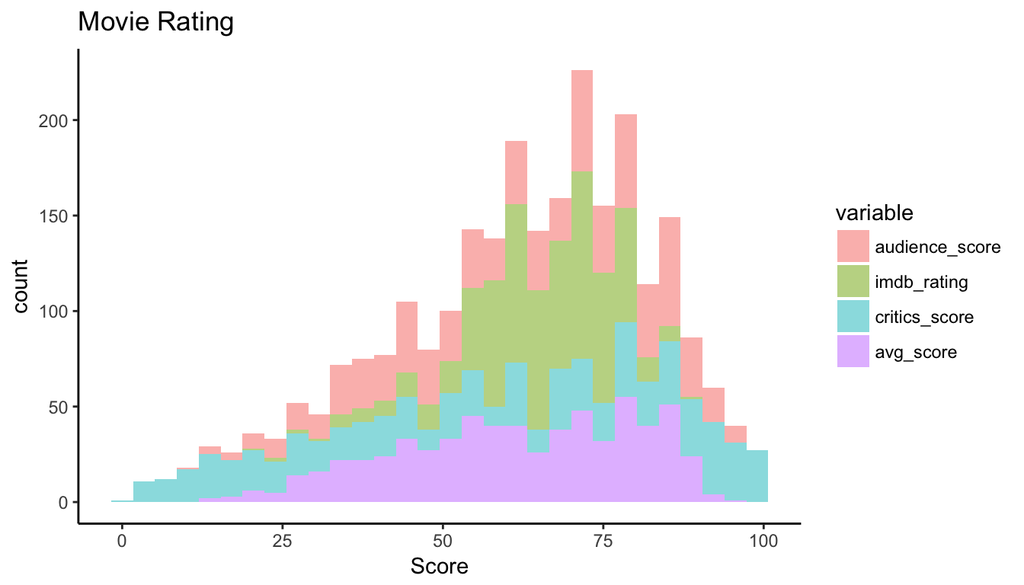

```r
# Subset to see the distributions of the scores
movies_score = movies[,c("title","audience_score","imdb_rating","critics_score","avg_score")]
movies_score$imdb_rating = movies_score$imdb_rating*10
movies_melted = melt(movies_score, id.vars = "title", measure.vars = c("audience_score","imdb_rating","critics_score","avg_score"))

# Histogram of the different Ratings
ggplot(movies_melted, aes(x= value) ) +
  geom_histogram(aes(fill=variable), position = "stack", alpha = 0.5) +
  theme_classic() + scale_x_continuous(name="Score") + ggtitle("Movie Rating")
```

Now the the variable `avg_score` is ready to be used as the explain variable for our analysis.

### About Explanatory Variables and Colinearity

Now lets see how the model would work out.

- Before everything, lets deal with the `NAs`

```r
# Removie NA
movies = na.omit(movies)
```

- First step is to remove: `audience_score`,`imdb_rating`,`critics_score`. These are the variables which are converted into the `avg_score`.
- Second, remove: `director`,`actor1`,`actor2`,`actor3`,`actor4`,`actor5`. These variables being categorical have a huge amount of levels which isn’t convinient to use for our model.

```r
# Number of different categories
apply( movies[,c("director","actor1","actor2","actor3","actor4","actor5","studio")] , 2, function(x){
  length(table(x))
})
```

```
## director   actor1   actor2   actor3   actor4   actor5   studio
##      504      461      550      580      590      598      202
```

- Third, remove the urls: `imdb_url`,`rt_url`. These variables provide no information for the model.
- Fourth, we need to check colinearity of the numerical variables in order to see if some should be dropped. We will set a threshold of $0.9$ in order to drop a variable if there exists colinearity.

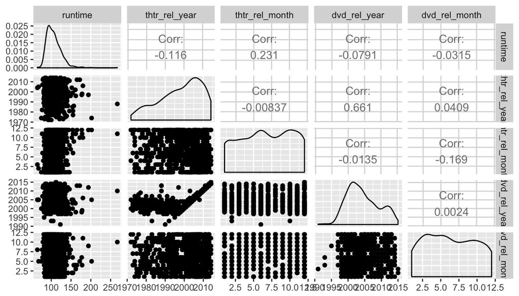

```r
# Define numerical variables
num_variables <- c("runtime", "thtr_rel_year", "thtr_rel_month", "dvd_rel_year",
                            "dvd_rel_month")
ggpairs(movies[,num_variables], columns = num_variables)
```

Since colinearity is not very high, the decision is to proceed with these variables.

Finally we will drop the variables that won’t be used in order to simplify the data set and not get confused.

```r
# Drop Variables
remove = c("title","audience_score","imdb_rating","critics_score",
           "director","actor1","actor2","actor3","actor4","actor5","studio",
           "imdb_url","rt_url")

# Dropping variables
movies = movies %>% select(-one_of(remove))
```

The final variables chosen to build the model are the following:

```r
pander(data.frame("Variables" = names(movies)))
```

| Variables |
| --- |
| title_type |
| genre |
| runtime |
| mpaa_rating |
| thtr_rel_year |
| thtr_rel_month |
| thtr_rel_day |
| dvd_rel_year |
| dvd_rel_month |
| dvd_rel_day |
| imdb_num_votes |
| critics_rating |
| audience_rating |
| best_pic_nom |
| best_pic_win |
| best_actor_win |
| best_actress_win |
| best_dir_win |
| top200_box |
| avg_score |

## Part 4: Modeling

In order to build our model we will use `backwards elimination` focusing on the significance of the variables with the `p-value` in order to discard the least significant ones. The decision is made with the purpose to fit less models, otherwise, the focus could rely on the highest *Adj. R-squared*.

```r
# Model 1
fit1 = lm(avg_score~., data = movies)
summary(fit1)
```

```
##
## Call:
## lm(formula = avg_score ~ ., data = movies)
##
## Residuals:
##      Min       1Q   Median       3Q      Max
## -26.9949  -4.5510   0.1807   5.1287  18.8310
##
## Coefficients:
##                                  Estimate Std. Error t value Pr(>|t|)
## (Intercept)                     3.605e+02  1.476e+02   2.443 0.014862 *
## title_typeFeature Film         -5.970e+00  3.012e+00  -1.982 0.047948 *
## title_typeTV Movie             -6.419e+00  4.839e+00  -1.327 0.185136
## genreAnimation                 -4.483e+00  3.113e+00  -1.440 0.150437
## genreArt House & International  1.641e+00  2.474e+00   0.663 0.507428
## genreComedy                     4.892e-03  1.283e+00   0.004 0.996960
## genreDocumentary                4.512e+00  3.171e+00   1.423 0.155335
## genreDrama                      3.198e+00  1.135e+00   2.818 0.004994 **
## genreHorror                     9.614e-01  1.929e+00   0.498 0.618469
## genreMusical & Performing Arts  6.711e+00  2.610e+00   2.572 0.010361 *
## genreMystery & Suspense         2.287e+00  1.455e+00   1.572 0.116518
## genreOther                      1.429e+00  2.226e+00   0.642 0.521070
## genreScience Fiction & Fantasy -1.682e+00  2.839e+00  -0.593 0.553621
## runtime                         3.847e-02  1.973e-02   1.950 0.051655 .
## mpaa_ratingNC-17               -8.285e+00  7.852e+00  -1.055 0.291782
## mpaa_ratingPG                  -4.549e+00  2.219e+00  -2.050 0.040782 *
## mpaa_ratingPG-13               -6.377e+00  2.309e+00  -2.762 0.005932 **
## mpaa_ratingR                   -5.390e+00  2.230e+00  -2.417 0.015974 *
## mpaa_ratingUnrated             -2.894e+00  2.665e+00  -1.086 0.277915
## thtr_rel_year                  -6.226e-02  4.258e-02  -1.462 0.144237
## thtr_rel_month                  8.829e-03  9.204e-02   0.096 0.923608
## thtr_rel_day                   -2.579e-03  3.503e-02  -0.074 0.941339
## dvd_rel_year                   -8.454e-02  9.191e-02  -0.920 0.358031
## dvd_rel_month                   1.243e-01  9.202e-02   1.351 0.177297
## dvd_rel_day                    -3.988e-02  3.454e-02  -1.155 0.248721
## imdb_num_votes                  1.355e-05  3.528e-06   3.840 0.000136 ***
## critics_ratingFresh            -3.495e+00  9.782e-01  -3.573 0.000383 ***
## critics_ratingRotten           -1.999e+01  1.022e+00 -19.566  < 2e-16 ***
## audience_ratingUpright          1.491e+01  7.785e-01  19.158  < 2e-16 ***
## best_pic_nomyes                 3.439e+00  1.993e+00   1.725 0.085000 .
## best_pic_winyes                -3.444e+00  3.493e+00  -0.986 0.324452
## best_actor_winyes               6.133e-01  9.126e-01   0.672 0.501857
## best_actress_winyes             1.459e-01  9.988e-01   0.146 0.883920
## best_dir_winyes                 1.958e+00  1.302e+00   1.504 0.133191
## top200_boxyes                  -2.021e+00  2.117e+00  -0.955 0.339943
## ---
## Signif. codes:  0 '***' 0.001 '**' 0.01 '*' 0.05 '.' 0.1 ' ' 1
##
## Residual standard error: 7.466 on 584 degrees of freedom
## Multiple R-squared:  0.8399, Adjusted R-squared:  0.8306
## F-statistic: 90.13 on 34 and 584 DF,  p-value: < 2.2e-16
```

The variable `thtr_rel_day` will be taken out, since it has the highest *p-value* while not belonging to a factor variable.

```r
# Model 2
fit2 = lm(avg_score~. -thtr_rel_day, data = movies)
summary(fit2)
```

```
##
## Call:
## lm(formula = avg_score ~ . - thtr_rel_day, data = movies)
##
## Residuals:
##      Min       1Q   Median       3Q      Max
## -26.9848  -4.5563   0.1703   5.1291  18.8476
##
## Coefficients:
##                                  Estimate Std. Error t value Pr(>|t|)
## (Intercept)                     3.604e+02  1.474e+02   2.444 0.014804 *
## title_typeFeature Film         -5.969e+00  3.010e+00  -1.983 0.047794 *
## title_typeTV Movie             -6.429e+00  4.833e+00  -1.330 0.183947
## genreAnimation                 -4.479e+00  3.110e+00  -1.440 0.150361
## genreArt House & International  1.628e+00  2.466e+00   0.660 0.509303
## genreComedy                     8.073e-03  1.282e+00   0.006 0.994976
## genreDocumentary                4.511e+00  3.169e+00   1.424 0.155110
## genreDrama                      3.197e+00  1.134e+00   2.820 0.004970 **
## genreHorror                     9.530e-01  1.924e+00   0.495 0.620632
## genreMusical & Performing Arts  6.709e+00  2.607e+00   2.573 0.010319 *
## genreMystery & Suspense         2.283e+00  1.453e+00   1.572 0.116595
## genreOther                      1.434e+00  2.223e+00   0.645 0.519015
## genreScience Fiction & Fantasy -1.670e+00  2.831e+00  -0.590 0.555483
## runtime                         3.849e-02  1.971e-02   1.953 0.051294 .
## mpaa_ratingNC-17               -8.304e+00  7.841e+00  -1.059 0.290037
## mpaa_ratingPG                  -4.552e+00  2.217e+00  -2.053 0.040487 *
## mpaa_ratingPG-13               -6.382e+00  2.306e+00  -2.767 0.005830 **
## mpaa_ratingR                   -5.388e+00  2.228e+00  -2.418 0.015914 *
## mpaa_ratingUnrated             -2.888e+00  2.661e+00  -1.085 0.278261
## thtr_rel_year                  -6.252e-02  4.239e-02  -1.475 0.140747
## thtr_rel_month                  8.123e-03  9.146e-02   0.089 0.929263
## dvd_rel_year                   -8.423e-02  9.173e-02  -0.918 0.358876
## dvd_rel_month                   1.244e-01  9.193e-02   1.353 0.176658
## dvd_rel_day                    -3.989e-02  3.451e-02  -1.156 0.248134
## imdb_num_votes                  1.355e-05  3.525e-06   3.843 0.000135 ***
## critics_ratingFresh            -3.488e+00  9.727e-01  -3.585 0.000365 ***
## critics_ratingRotten           -1.998e+01  1.018e+00 -19.635  < 2e-16 ***
## audience_ratingUpright          1.491e+01  7.777e-01  19.175  < 2e-16 ***
## best_pic_nomyes                 3.445e+00  1.990e+00   1.731 0.083952 .
## best_pic_winyes                -3.452e+00  3.488e+00  -0.990 0.322692
## best_actor_winyes               6.122e-01  9.117e-01   0.671 0.502188
## best_actress_winyes             1.442e-01  9.977e-01   0.144 0.885161
## best_dir_winyes                 1.960e+00  1.301e+00   1.507 0.132428
## top200_boxyes                  -2.019e+00  2.114e+00  -0.955 0.340112
## ---
## Signif. codes:  0 '***' 0.001 '**' 0.01 '*' 0.05 '.' 0.1 ' ' 1
##
## Residual standard error: 7.46 on 585 degrees of freedom
## Multiple R-squared:  0.8399, Adjusted R-squared:  0.8309
## F-statistic: 93.02 on 33 and 585 DF,  p-value: < 2.2e-16
```

Now we remove `thtr_rel_month` which has a p-value of $0.92$.

```r
# Model 3
fit3 = lm(avg_score~. - thtr_rel_day - thtr_rel_month, data = movies)
summary(fit3)
```

```
##
## Call:
## lm(formula = avg_score ~ . - thtr_rel_day - thtr_rel_month, data = movies)
##
## Residuals:
##      Min       1Q   Median       3Q      Max
## -27.0084  -4.5604   0.1572   5.1129  18.8784
##
## Coefficients:
##                                  Estimate Std. Error t value Pr(>|t|)
## (Intercept)                     3.603e+02  1.473e+02   2.446 0.014734 *
## title_typeFeature Film         -5.967e+00  3.007e+00  -1.984 0.047679 *
## title_typeTV Movie             -6.452e+00  4.821e+00  -1.338 0.181314
## genreAnimation                 -4.473e+00  3.107e+00  -1.440 0.150467
## genreArt House & International  1.630e+00  2.464e+00   0.662 0.508385
## genreComedy                     1.226e-02  1.280e+00   0.010 0.992361
## genreDocumentary                4.516e+00  3.165e+00   1.427 0.154216
## genreDrama                      3.194e+00  1.132e+00   2.821 0.004954 **
## genreHorror                     9.561e-01  1.922e+00   0.497 0.619115
## genreMusical & Performing Arts  6.711e+00  2.605e+00   2.577 0.010220 *
## genreMystery & Suspense         2.275e+00  1.448e+00   1.570 0.116850
## genreOther                      1.418e+00  2.213e+00   0.641 0.522011
## genreScience Fiction & Fantasy -1.675e+00  2.828e+00  -0.592 0.553877
## runtime                         3.884e-02  1.929e-02   2.013 0.044552 *
## mpaa_ratingNC-17               -8.262e+00  7.821e+00  -1.056 0.291182
## mpaa_ratingPG                  -4.545e+00  2.214e+00  -2.053 0.040494 *
## mpaa_ratingPG-13               -6.384e+00  2.304e+00  -2.771 0.005769 **
## mpaa_ratingR                   -5.382e+00  2.226e+00  -2.418 0.015892 *
## mpaa_ratingUnrated             -2.885e+00  2.659e+00  -1.085 0.278314
## thtr_rel_year                  -6.236e-02  4.231e-02  -1.474 0.141069
## dvd_rel_year                   -8.436e-02  9.165e-02  -0.920 0.357712
## dvd_rel_month                   1.230e-01  9.049e-02   1.359 0.174727
## dvd_rel_day                    -3.981e-02  3.447e-02  -1.155 0.248553
## imdb_num_votes                  1.355e-05  3.522e-06   3.848 0.000132 ***
## critics_ratingFresh            -3.487e+00  9.719e-01  -3.588 0.000361 ***
## critics_ratingRotten           -1.998e+01  1.017e+00 -19.652  < 2e-16 ***
## audience_ratingUpright          1.491e+01  7.769e-01  19.193  < 2e-16 ***
## best_pic_nomyes                 3.469e+00  1.970e+00   1.761 0.078810 .
## best_pic_winyes                -3.474e+00  3.477e+00  -0.999 0.318134
## best_actor_winyes               6.145e-01  9.106e-01   0.675 0.500039
## best_actress_winyes             1.435e-01  9.968e-01   0.144 0.885563
## best_dir_winyes                 1.962e+00  1.300e+00   1.510 0.131582
## top200_boxyes                  -2.007e+00  2.109e+00  -0.952 0.341576
## ---
## Signif. codes:  0 '***' 0.001 '**' 0.01 '*' 0.05 '.' 0.1 ' ' 1
##
## Residual standard error: 7.453 on 586 degrees of freedom
## Multiple R-squared:  0.8399, Adjusted R-squared:  0.8312
## F-statistic: 96.09 on 32 and 586 DF,  p-value: < 2.2e-16
```

Now we will remove `best_actress_win`.

```r
# Model 4
fit4 = lm(avg_score~. - thtr_rel_day - thtr_rel_month -
            best_actress_win, data = movies)
summary(fit4)
```

```
##
## Call:
## lm(formula = avg_score ~ . - thtr_rel_day - thtr_rel_month -
##     best_actress_win, data = movies)
##
## Residuals:
##      Min       1Q   Median       3Q      Max
## -27.0219  -4.5714   0.1417   5.0788  19.0071
##
## Coefficients:
##                                  Estimate Std. Error t value Pr(>|t|)
## (Intercept)                     3.616e+02  1.469e+02   2.462 0.014118 *
## title_typeFeature Film         -5.969e+00  3.005e+00  -1.987 0.047414 *
## title_typeTV Movie             -6.431e+00  4.815e+00  -1.336 0.182165
## genreAnimation                 -4.449e+00  3.100e+00  -1.435 0.151763
## genreArt House & International  1.650e+00  2.458e+00   0.671 0.502374
## genreComedy                     2.972e-02  1.273e+00   0.023 0.981380
## genreDocumentary                4.527e+00  3.162e+00   1.432 0.152747
## genreDrama                      3.216e+00  1.121e+00   2.868 0.004283 **
## genreHorror                     9.641e-01  1.920e+00   0.502 0.615747
## genreMusical & Performing Arts  6.714e+00  2.602e+00   2.580 0.010128 *
## genreMystery & Suspense         2.300e+00  1.436e+00   1.602 0.109735
## genreOther                      1.433e+00  2.209e+00   0.649 0.516788
## genreScience Fiction & Fantasy -1.673e+00  2.826e+00  -0.592 0.554037
## runtime                         3.912e-02  1.918e-02   2.040 0.041841 *
## mpaa_ratingNC-17               -8.281e+00  7.813e+00  -1.060 0.289642
## mpaa_ratingPG                  -4.541e+00  2.212e+00  -2.053 0.040488 *
## mpaa_ratingPG-13               -6.382e+00  2.302e+00  -2.772 0.005747 **
## mpaa_ratingR                   -5.384e+00  2.224e+00  -2.421 0.015774 *
## mpaa_ratingUnrated             -2.886e+00  2.657e+00  -1.086 0.277723
## thtr_rel_year                  -6.227e-02  4.227e-02  -1.473 0.141270
## dvd_rel_year                   -8.511e-02  9.142e-02  -0.931 0.352271
## dvd_rel_month                   1.230e-01  9.041e-02   1.361 0.174076
## dvd_rel_day                    -3.983e-02  3.444e-02  -1.157 0.247855
## imdb_num_votes                  1.355e-05  3.519e-06   3.851 0.000131 ***
## critics_ratingFresh            -3.496e+00  9.690e-01  -3.608 0.000335 ***
## critics_ratingRotten           -1.999e+01  1.015e+00 -19.685  < 2e-16 ***
## audience_ratingUpright          1.491e+01  7.757e-01  19.218  < 2e-16 ***
## best_pic_nomyes                 3.497e+00  1.959e+00   1.785 0.074763 .
## best_pic_winyes                -3.451e+00  3.470e+00  -0.994 0.320428
## best_actor_winyes               6.214e-01  9.086e-01   0.684 0.494328
## best_dir_winyes                 1.963e+00  1.298e+00   1.512 0.131161
## top200_boxyes                  -1.993e+00  2.105e+00  -0.947 0.344052
## ---
## Signif. codes:  0 '***' 0.001 '**' 0.01 '*' 0.05 '.' 0.1 ' ' 1
##
## Residual standard error: 7.447 on 587 degrees of freedom
## Multiple R-squared:  0.8399, Adjusted R-squared:  0.8315
## F-statistic: 99.36 on 31 and 587 DF,  p-value: < 2.2e-16
```

Now we will remove `best_actor_win`.

```r
# Model 5
fit5 = lm(avg_score~. - thtr_rel_day - thtr_rel_month -
            best_actress_win - best_actor_win, data = movies)
summary(fit5)
```

```
##
## Call:
## lm(formula = avg_score ~ . - thtr_rel_day - thtr_rel_month -
##     best_actress_win - best_actor_win, data = movies)
##
## Residuals:
##     Min      1Q  Median      3Q     Max
## -26.554  -4.510   0.027   5.124  18.932
##
## Coefficients:
##                                  Estimate Std. Error t value Pr(>|t|)
## (Intercept)                     3.703e+02  1.463e+02   2.532 0.011608 *
## title_typeFeature Film         -5.932e+00  3.003e+00  -1.976 0.048663 *
## title_typeTV Movie             -6.483e+00  4.812e+00  -1.347 0.178464
## genreAnimation                 -4.389e+00  3.097e+00  -1.417 0.156934
## genreArt House & International  1.610e+00  2.456e+00   0.656 0.512367
## genreComedy                     3.226e-02  1.272e+00   0.025 0.979781
## genreDocumentary                4.545e+00  3.160e+00   1.438 0.150958
## genreDrama                      3.245e+00  1.120e+00   2.897 0.003908 **
## genreHorror                     9.369e-01  1.919e+00   0.488 0.625509
## genreMusical & Performing Arts  6.694e+00  2.601e+00   2.574 0.010305 *
## genreMystery & Suspense         2.395e+00  1.429e+00   1.677 0.094124 .
## genreOther                      1.449e+00  2.208e+00   0.656 0.511797
## genreScience Fiction & Fantasy -1.727e+00  2.824e+00  -0.612 0.540994
## runtime                         4.169e-02  1.880e-02   2.217 0.026975 *
## mpaa_ratingNC-17               -8.275e+00  7.810e+00  -1.060 0.289772
## mpaa_ratingPG                  -4.487e+00  2.209e+00  -2.031 0.042681 *
## mpaa_ratingPG-13               -6.366e+00  2.301e+00  -2.767 0.005842 **
## mpaa_ratingR                   -5.372e+00  2.223e+00  -2.417 0.015950 *
## mpaa_ratingUnrated             -2.870e+00  2.655e+00  -1.081 0.280265
## thtr_rel_year                  -6.051e-02  4.218e-02  -1.435 0.151918
## dvd_rel_year                   -9.133e-02  9.093e-02  -1.004 0.315607
## dvd_rel_month                   1.174e-01  8.999e-02   1.304 0.192639
## dvd_rel_day                    -4.018e-02  3.442e-02  -1.168 0.243465
## imdb_num_votes                  1.350e-05  3.516e-06   3.839 0.000137 ***
## critics_ratingFresh            -3.486e+00  9.685e-01  -3.599 0.000346 ***
## critics_ratingRotten           -2.000e+01  1.015e+00 -19.701  < 2e-16 ***
## audience_ratingUpright          1.488e+01  7.742e-01  19.218  < 2e-16 ***
## best_pic_nomyes                 3.668e+00  1.942e+00   1.889 0.059398 .
## best_pic_winyes                -3.624e+00  3.459e+00  -1.047 0.295302
## best_dir_winyes                 1.994e+00  1.297e+00   1.537 0.124848
## top200_boxyes                  -1.951e+00  2.103e+00  -0.928 0.353929
## ---
## Signif. codes:  0 '***' 0.001 '**' 0.01 '*' 0.05 '.' 0.1 ' ' 1
##
## Residual standard error: 7.444 on 588 degrees of freedom
## Multiple R-squared:  0.8398, Adjusted R-squared:  0.8316
## F-statistic: 102.7 on 30 and 588 DF,  p-value: < 2.2e-16
```

Now we will remove `top200_box`.

```r
# Model 6
fit6 = lm(avg_score~. - thtr_rel_day - thtr_rel_month -
            best_actress_win - best_actor_win -top200_box, data = movies)
summary(fit6)
```

```
##
## Call:
## lm(formula = avg_score ~ . - thtr_rel_day - thtr_rel_month -
##     best_actress_win - best_actor_win - top200_box, data = movies)
##
## Residuals:
##      Min       1Q   Median       3Q      Max
## -26.4316  -4.5683  -0.0117   5.1066  18.9312
##
## Coefficients:
##                                  Estimate Std. Error t value Pr(>|t|)
## (Intercept)                     3.646e+02  1.461e+02   2.495 0.012870 *
## title_typeFeature Film         -5.956e+00  3.002e+00  -1.984 0.047732 *
## title_typeTV Movie             -6.537e+00  4.811e+00  -1.359 0.174779
## genreAnimation                 -4.125e+00  3.083e+00  -1.338 0.181465
## genreArt House & International  1.691e+00  2.454e+00   0.689 0.490978
## genreComedy                     1.124e-01  1.269e+00   0.089 0.929485
## genreDocumentary                4.619e+00  3.159e+00   1.462 0.144199
## genreDrama                      3.326e+00  1.116e+00   2.979 0.003014 **
## genreHorror                     9.987e-01  1.917e+00   0.521 0.602662
## genreMusical & Performing Arts  6.800e+00  2.598e+00   2.617 0.009094 **
## genreMystery & Suspense         2.473e+00  1.426e+00   1.734 0.083438 .
## genreOther                      1.530e+00  2.206e+00   0.694 0.488227
## genreScience Fiction & Fantasy -1.788e+00  2.823e+00  -0.633 0.526673
## runtime                         4.086e-02  1.878e-02   2.176 0.029953 *
## mpaa_ratingNC-17               -7.967e+00  7.802e+00  -1.021 0.307585
## mpaa_ratingPG                  -4.329e+00  2.202e+00  -1.966 0.049792 *
## mpaa_ratingPG-13               -6.152e+00  2.289e+00  -2.688 0.007400 **
## mpaa_ratingR                   -5.119e+00  2.206e+00  -2.321 0.020630 *
## mpaa_ratingUnrated             -2.662e+00  2.645e+00  -1.006 0.314660
## thtr_rel_year                  -5.807e-02  4.209e-02  -1.380 0.168206
## dvd_rel_year                   -9.100e-02  9.092e-02  -1.001 0.317246
## dvd_rel_month                   1.173e-01  8.998e-02   1.304 0.192790
## dvd_rel_day                    -4.037e-02  3.441e-02  -1.173 0.241165
## imdb_num_votes                  1.281e-05  3.436e-06   3.728 0.000212 ***
## critics_ratingFresh            -3.412e+00  9.651e-01  -3.536 0.000439 ***
## critics_ratingRotten           -1.993e+01  1.012e+00 -19.690  < 2e-16 ***
## audience_ratingUpright          1.487e+01  7.741e-01  19.215  < 2e-16 ***
## best_pic_nomyes                 3.723e+00  1.941e+00   1.918 0.055564 .
## best_pic_winyes                -3.599e+00  3.459e+00  -1.041 0.298467
## best_dir_winyes                 2.030e+00  1.296e+00   1.566 0.117834
## ---
## Signif. codes:  0 '***' 0.001 '**' 0.01 '*' 0.05 '.' 0.1 ' ' 1
##
## Residual standard error: 7.443 on 589 degrees of freedom
## Multiple R-squared:  0.8396, Adjusted R-squared:  0.8317
## F-statistic: 106.3 on 29 and 589 DF,  p-value: < 2.2e-16
```

Now we will remove `dvd_rel_year`.

```r
# Model 7
fit7 = lm(avg_score~. - thtr_rel_day - thtr_rel_month -
            best_actress_win - best_actor_win -top200_box -
            dvd_rel_year, data = movies)
summary(fit7)
```

```
##
## Call:
## lm(formula = avg_score ~ . - thtr_rel_day - thtr_rel_month -
##     best_actress_win - best_actor_win - top200_box - dvd_rel_year,
##     data = movies)
##
## Residuals:
##      Min       1Q   Median       3Q      Max
## -26.1104  -4.4762   0.0087   5.1231  18.6096
##
## Coefficients:
##                                  Estimate Std. Error t value Pr(>|t|)
## (Intercept)                     2.342e+02  6.626e+01   3.535 0.000440 ***
## title_typeFeature Film         -5.875e+00  3.001e+00  -1.958 0.050735 .
## title_typeTV Movie             -6.260e+00  4.803e+00  -1.303 0.193025
## genreAnimation                 -4.170e+00  3.083e+00  -1.352 0.176764
## genreArt House & International  1.539e+00  2.450e+00   0.628 0.529987
## genreComedy                     1.270e-01  1.269e+00   0.100 0.920328
## genreDocumentary                4.582e+00  3.159e+00   1.451 0.147403
## genreDrama                      3.277e+00  1.115e+00   2.938 0.003432 **
## genreHorror                     8.522e-01  1.912e+00   0.446 0.655932
## genreMusical & Performing Arts  6.715e+00  2.597e+00   2.586 0.009953 **
## genreMystery & Suspense         2.409e+00  1.425e+00   1.691 0.091343 .
## genreOther                      1.414e+00  2.203e+00   0.642 0.521195
## genreScience Fiction & Fantasy -1.883e+00  2.821e+00  -0.667 0.504785
## runtime                         4.102e-02  1.878e-02   2.185 0.029297 *
## mpaa_ratingNC-17               -7.711e+00  7.797e+00  -0.989 0.323130
## mpaa_ratingPG                  -4.354e+00  2.202e+00  -1.977 0.048497 *
## mpaa_ratingPG-13               -6.084e+00  2.288e+00  -2.659 0.008056 **
## mpaa_ratingR                   -5.022e+00  2.203e+00  -2.279 0.023023 *
## mpaa_ratingUnrated             -2.769e+00  2.643e+00  -1.048 0.295250
## thtr_rel_year                  -8.422e-02  3.300e-02  -2.552 0.010972 *
## dvd_rel_month                   1.206e-01  8.992e-02   1.341 0.180405
## dvd_rel_day                    -3.710e-02  3.426e-02  -1.083 0.279237
## imdb_num_votes                  1.267e-05  3.433e-06   3.690 0.000245 ***
## critics_ratingFresh            -3.472e+00  9.633e-01  -3.604 0.000340 ***
## critics_ratingRotten           -1.990e+01  1.012e+00 -19.670  < 2e-16 ***
## audience_ratingUpright          1.496e+01  7.699e-01  19.426  < 2e-16 ***
## best_pic_nomyes                 3.667e+00  1.940e+00   1.890 0.059229 .
## best_pic_winyes                -3.717e+00  3.457e+00  -1.075 0.282670
## best_dir_winyes                 2.066e+00  1.296e+00   1.594 0.111401
## ---
## Signif. codes:  0 '***' 0.001 '**' 0.01 '*' 0.05 '.' 0.1 ' ' 1
##
## Residual standard error: 7.443 on 590 degrees of freedom
## Multiple R-squared:  0.8393, Adjusted R-squared:  0.8317
## F-statistic:   110 on 28 and 590 DF,  p-value: < 2.2e-16
```

Now we will remove `best_pic_win`

```r
# Model 8
fit8 = lm(avg_score~. - thtr_rel_day - thtr_rel_month -
            best_actress_win - best_actor_win -top200_box -
            dvd_rel_year - best_pic_win, data = movies)
summary(fit8)
```

```
##
## Call:
## lm(formula = avg_score ~ . - thtr_rel_day - thtr_rel_month -
##     best_actress_win - best_actor_win - top200_box - dvd_rel_year -
##     best_pic_win, data = movies)
##
## Residuals:
##     Min      1Q  Median      3Q     Max
## -26.137  -4.523   0.000   5.156  18.604
##
## Coefficients:
##                                  Estimate Std. Error t value Pr(>|t|)
## (Intercept)                     2.301e+02  6.616e+01   3.477 0.000543 ***
## title_typeFeature Film         -5.851e+00  3.001e+00  -1.950 0.051705 .
## title_typeTV Movie             -6.302e+00  4.804e+00  -1.312 0.190092
## genreAnimation                 -4.195e+00  3.083e+00  -1.361 0.174160
## genreArt House & International  1.461e+00  2.449e+00   0.597 0.550929
## genreComedy                     6.206e-02  1.268e+00   0.049 0.960975
## genreDocumentary                4.518e+00  3.159e+00   1.430 0.153178
## genreDrama                      3.244e+00  1.115e+00   2.909 0.003758 **
## genreHorror                     8.264e-01  1.912e+00   0.432 0.665725
## genreMusical & Performing Arts  6.689e+00  2.597e+00   2.576 0.010251 *
## genreMystery & Suspense         2.374e+00  1.424e+00   1.667 0.096094 .
## genreOther                      1.562e+00  2.199e+00   0.710 0.477883
## genreScience Fiction & Fantasy -1.847e+00  2.821e+00  -0.655 0.512891
## runtime                         4.119e-02  1.878e-02   2.193 0.028676 *
## mpaa_ratingNC-17               -7.713e+00  7.798e+00  -0.989 0.323048
## mpaa_ratingPG                  -4.358e+00  2.202e+00  -1.979 0.048305 *
## mpaa_ratingPG-13               -6.032e+00  2.288e+00  -2.636 0.008603 **
## mpaa_ratingR                   -5.003e+00  2.204e+00  -2.270 0.023547 *
## mpaa_ratingUnrated             -2.803e+00  2.643e+00  -1.060 0.289399
## thtr_rel_year                  -8.215e-02  3.295e-02  -2.493 0.012944 *
## dvd_rel_month                   1.255e-01  8.982e-02   1.397 0.162800
## dvd_rel_day                    -3.845e-02  3.424e-02  -1.123 0.261907
## imdb_num_votes                  1.204e-05  3.383e-06   3.558 0.000403 ***
## critics_ratingFresh            -3.418e+00  9.621e-01  -3.552 0.000412 ***
## critics_ratingRotten           -1.989e+01  1.012e+00 -19.657  < 2e-16 ***
## audience_ratingUpright          1.499e+01  7.694e-01  19.480  < 2e-16 ***
## best_pic_nomyes                 2.848e+00  1.785e+00   1.596 0.111041
## best_dir_winyes                 1.696e+00  1.249e+00   1.357 0.175269
## ---
## Signif. codes:  0 '***' 0.001 '**' 0.01 '*' 0.05 '.' 0.1 ' ' 1
##
## Residual standard error: 7.444 on 591 degrees of freedom
## Multiple R-squared:  0.839,  Adjusted R-squared:  0.8316
## F-statistic:   114 on 27 and 591 DF,  p-value: < 2.2e-16
```

Now we will remove `dvd_rel_day`

```r
# Model 9
fit9 = lm(avg_score~. - thtr_rel_day - thtr_rel_month -
            best_actress_win - best_actor_win -top200_box -
            dvd_rel_year - best_pic_win - dvd_rel_day, data = movies)
summary(fit9)
```

```
##
## Call:
## lm(formula = avg_score ~ . - thtr_rel_day - thtr_rel_month -
##     best_actress_win - best_actor_win - top200_box - dvd_rel_year -
##     best_pic_win - dvd_rel_day, data = movies)
##
## Residuals:
##      Min       1Q   Median       3Q      Max
## -26.1956  -4.5951   0.0804   5.2384  18.8718
##
## Coefficients:
##                                  Estimate Std. Error t value Pr(>|t|)
## (Intercept)                     2.292e+02  6.617e+01   3.464 0.000571 ***
## title_typeFeature Film         -5.805e+00  3.002e+00  -1.934 0.053626 .
## title_typeTV Movie             -6.124e+00  4.802e+00  -1.275 0.202767
## genreAnimation                 -4.303e+00  3.083e+00  -1.396 0.163240
## genreArt House & International  1.505e+00  2.449e+00   0.614 0.539196
## genreComedy                     4.123e-02  1.268e+00   0.033 0.974069
## genreDocumentary                4.519e+00  3.159e+00   1.430 0.153121
## genreDrama                      3.167e+00  1.113e+00   2.845 0.004596 **
## genreHorror                     8.588e-01  1.912e+00   0.449 0.653472
## genreMusical & Performing Arts  6.538e+00  2.594e+00   2.520 0.011989 *
## genreMystery & Suspense         2.321e+00  1.424e+00   1.630 0.103599
## genreOther                      1.414e+00  2.195e+00   0.644 0.519864
## genreScience Fiction & Fantasy -2.006e+00  2.818e+00  -0.712 0.476803
## runtime                         4.170e-02  1.878e-02   2.221 0.026746 *
## mpaa_ratingNC-17               -7.875e+00  7.799e+00  -1.010 0.313011
## mpaa_ratingPG                  -4.425e+00  2.202e+00  -2.009 0.044976 *
## mpaa_ratingPG-13               -6.160e+00  2.286e+00  -2.695 0.007233 **
## mpaa_ratingR                   -5.098e+00  2.203e+00  -2.314 0.020983 *
## mpaa_ratingUnrated             -2.957e+00  2.641e+00  -1.120 0.263222
## thtr_rel_year                  -8.196e-02  3.296e-02  -2.487 0.013171 *
## dvd_rel_month                   1.288e-01  8.979e-02   1.435 0.151950
## imdb_num_votes                  1.217e-05  3.381e-06   3.600 0.000345 ***
## critics_ratingFresh            -3.425e+00  9.623e-01  -3.559 0.000402 ***
## critics_ratingRotten           -1.996e+01  1.010e+00 -19.767  < 2e-16 ***
## audience_ratingUpright          1.492e+01  7.673e-01  19.447  < 2e-16 ***
## best_pic_nomyes                 2.757e+00  1.783e+00   1.546 0.122530
## best_dir_winyes                 1.633e+00  1.248e+00   1.308 0.191462
## ---
## Signif. codes:  0 '***' 0.001 '**' 0.01 '*' 0.05 '.' 0.1 ' ' 1
##
## Residual standard error: 7.446 on 592 degrees of freedom
## Multiple R-squared:  0.8386, Adjusted R-squared:  0.8315
## F-statistic: 118.3 on 26 and 592 DF,  p-value: < 2.2e-16
```

Now we will remove `best_dir_win`

```r
# Model 10
fit10 = lm(avg_score~. - thtr_rel_day - thtr_rel_month -
            best_actress_win - best_actor_win -top200_box -
            dvd_rel_year - best_pic_win - dvd_rel_day -
            best_dir_win, data = movies)
summary(fit10)
```

```
##
## Call:
## lm(formula = avg_score ~ . - thtr_rel_day - thtr_rel_month -
##     best_actress_win - best_actor_win - top200_box - dvd_rel_year -
##     best_pic_win - dvd_rel_day - best_dir_win, data = movies)
##
## Residuals:
##      Min       1Q   Median       3Q      Max
## -26.3608  -4.7661   0.0553   5.2677  18.7992
##
## Coefficients:
##                                  Estimate Std. Error t value Pr(>|t|)
## (Intercept)                     2.354e+02  6.604e+01   3.565 0.000394 ***
## title_typeFeature Film         -5.674e+00  3.002e+00  -1.890 0.059230 .
## title_typeTV Movie             -6.043e+00  4.805e+00  -1.258 0.209005
## genreAnimation                 -4.282e+00  3.084e+00  -1.388 0.165577
## genreArt House & International  1.427e+00  2.450e+00   0.582 0.560591
## genreComedy                     4.587e-02  1.269e+00   0.036 0.971167
## genreDocumentary                4.578e+00  3.161e+00   1.448 0.148065
## genreDrama                      3.139e+00  1.114e+00   2.819 0.004982 **
## genreHorror                     8.713e-01  1.913e+00   0.455 0.648978
## genreMusical & Performing Arts  6.556e+00  2.596e+00   2.526 0.011810 *
## genreMystery & Suspense         2.325e+00  1.425e+00   1.632 0.103264
## genreOther                      1.278e+00  2.194e+00   0.583 0.560409
## genreScience Fiction & Fantasy -1.944e+00  2.819e+00  -0.690 0.490768
## runtime                         4.577e-02  1.853e-02   2.470 0.013791 *
## mpaa_ratingNC-17               -7.794e+00  7.803e+00  -0.999 0.318275
## mpaa_ratingPG                  -4.303e+00  2.202e+00  -1.955 0.051087 .
## mpaa_ratingPG-13               -6.076e+00  2.286e+00  -2.658 0.008079 **
## mpaa_ratingR                   -4.979e+00  2.202e+00  -2.261 0.024120 *
## mpaa_ratingUnrated             -2.901e+00  2.642e+00  -1.098 0.272568
## thtr_rel_year                  -8.528e-02  3.288e-02  -2.594 0.009734 **
## dvd_rel_month                   1.206e-01  8.962e-02   1.345 0.179033
## imdb_num_votes                  1.255e-05  3.371e-06   3.722 0.000216 ***
## critics_ratingFresh            -3.423e+00  9.629e-01  -3.555 0.000408 ***
## critics_ratingRotten           -2.006e+01  1.007e+00 -19.914  < 2e-16 ***
## audience_ratingUpright          1.488e+01  7.671e-01  19.398  < 2e-16 ***
## best_pic_nomyes                 2.880e+00  1.782e+00   1.616 0.106567
## ---
## Signif. codes:  0 '***' 0.001 '**' 0.01 '*' 0.05 '.' 0.1 ' ' 1
##
## Residual standard error: 7.45 on 593 degrees of freedom
## Multiple R-squared:  0.8382, Adjusted R-squared:  0.8313
## F-statistic: 122.9 on 25 and 593 DF,  p-value: < 2.2e-16
```

```r
# Model 11
fit11 = lm(avg_score~. - thtr_rel_day - thtr_rel_month -
            best_actress_win - best_actor_win -top200_box -
            dvd_rel_year - best_pic_win - dvd_rel_day -
            best_dir_win - dvd_rel_month - best_pic_nom, data = movies)
summary(fit11)
```

```
##
## Call:
## lm(formula = avg_score ~ . - thtr_rel_day - thtr_rel_month -
##     best_actress_win - best_actor_win - top200_box - dvd_rel_year -
##     best_pic_win - dvd_rel_day - best_dir_win - dvd_rel_month -
##     best_pic_nom, data = movies)
##
## Residuals:
##      Min       1Q   Median       3Q      Max
## -27.0376  -4.5399   0.0757   5.2320  18.4254
##
## Coefficients:
##                                  Estimate Std. Error t value Pr(>|t|)
## (Intercept)                     2.401e+02  6.603e+01   3.636 0.000301 ***
## title_typeFeature Film         -5.426e+00  3.004e+00  -1.806 0.071378 .
## title_typeTV Movie             -5.585e+00  4.805e+00  -1.162 0.245526
## genreAnimation                 -4.418e+00  3.087e+00  -1.431 0.152873
## genreArt House & International  1.505e+00  2.454e+00   0.613 0.539956
## genreComedy                     5.415e-02  1.267e+00   0.043 0.965930
## genreDocumentary                4.908e+00  3.162e+00   1.552 0.121132
## genreDrama                      3.188e+00  1.111e+00   2.869 0.004259 **
## genreHorror                     9.918e-01  1.915e+00   0.518 0.604686
## genreMusical & Performing Arts  6.436e+00  2.599e+00   2.476 0.013563 *
## genreMystery & Suspense         2.343e+00  1.425e+00   1.644 0.100635
## genreOther                      1.430e+00  2.193e+00   0.652 0.514678
## genreScience Fiction & Fantasy -1.840e+00  2.823e+00  -0.652 0.514736
## runtime                         4.946e-02  1.837e-02   2.693 0.007279 **
## mpaa_ratingNC-17               -7.403e+00  7.806e+00  -0.948 0.343332
## mpaa_ratingPG                  -4.181e+00  2.205e+00  -1.896 0.058429 .
## mpaa_ratingPG-13               -5.995e+00  2.290e+00  -2.618 0.009072 **
## mpaa_ratingR                   -4.923e+00  2.206e+00  -2.232 0.026003 *
## mpaa_ratingUnrated             -2.901e+00  2.647e+00  -1.096 0.273527
## thtr_rel_year                  -8.750e-02  3.286e-02  -2.663 0.007957 **
## imdb_num_votes                  1.355e-05  3.324e-06   4.078 5.15e-05 ***
## critics_ratingFresh            -3.675e+00  9.555e-01  -3.847 0.000133 ***
## critics_ratingRotten           -2.032e+01  9.994e-01 -20.336  < 2e-16 ***
## audience_ratingUpright          1.493e+01  7.682e-01  19.430  < 2e-16 ***
## ---
## Signif. codes:  0 '***' 0.001 '**' 0.01 '*' 0.05 '.' 0.1 ' ' 1
##
## Residual standard error: 7.465 on 595 degrees of freedom
## Multiple R-squared:  0.837,  Adjusted R-squared:  0.8307
## F-statistic: 132.8 on 23 and 595 DF,  p-value: < 2.2e-16
```

#### Residuals

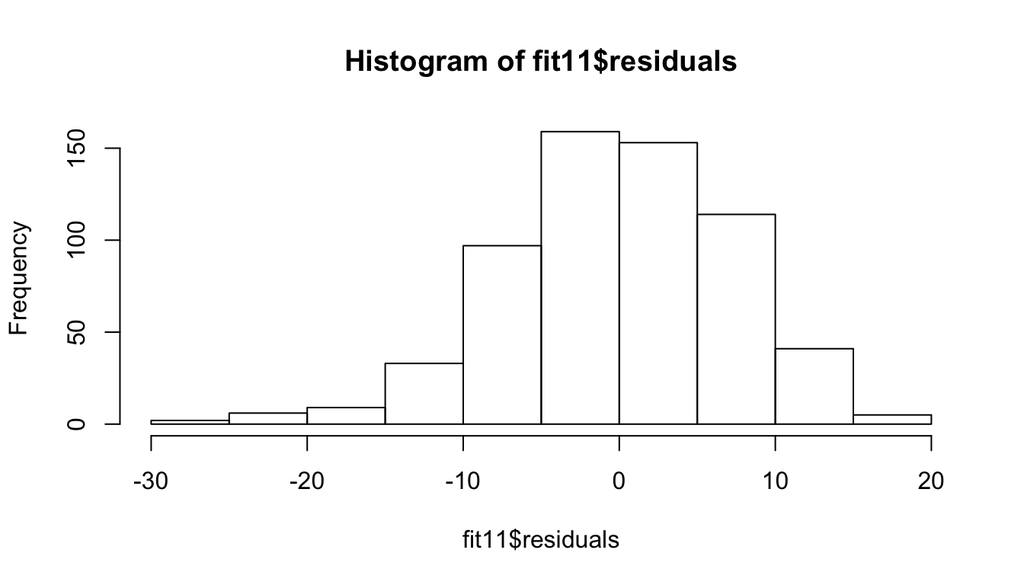

```r
hist(fit11$residuals)
```

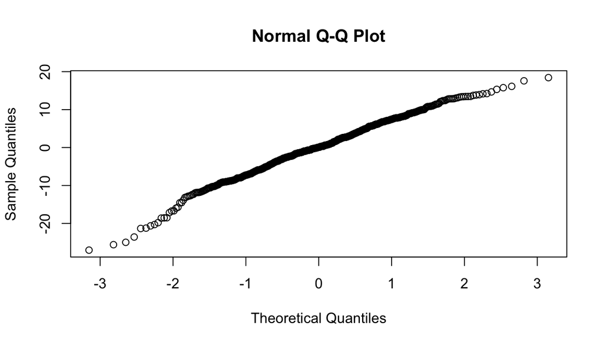

```r
qqnorm(fit11$residuals)
```

Residuals seem to be normally distributed with a little left skew.

To see the variability of our residuals

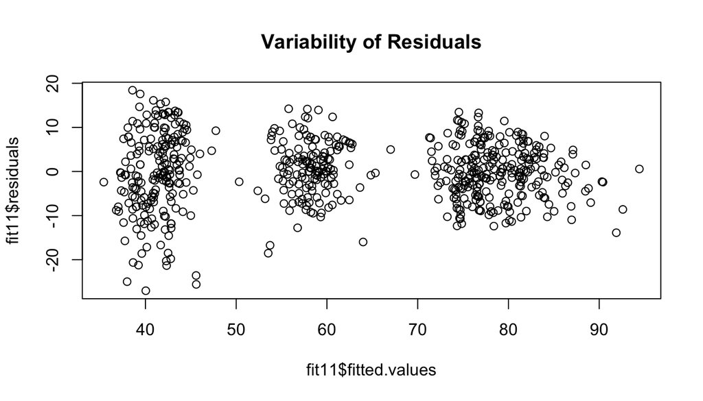

```r
plot(fit11$residuals ~ fit11$fitted.values, main="Variability of Residuals")
```

The residuals seem to be scattered around 0. The model seems to have more variance on the lower ratings.

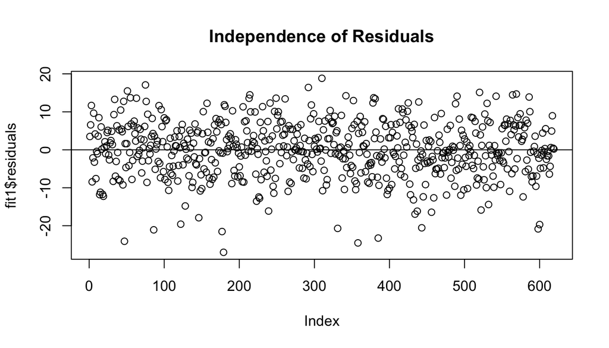

```r
plot(fit1$residuals, main="Independence of Residuals")
abline(h = 0)
```

#### About the Coefficients

There is no wonder that the variables, `critics_rating` and `audience_rating` show a high significance in the model. These are basically a categorical representation of the score, and our objective is to find the variables which help to predict the score of the movie.